# Overview of `comrad`

26/01/2023

## Introduction and biological context

`comrad` is an individual-based simulation of an evolving community of organisms. At every (discrete, non-overlapping) generation, individuals sample a number of offspring in a Poisson with parameter their fitness value. Offspring undergo mutation and (when the criterion is met) ecological speciation, then replace the parent community.

Competition between individuals causes selection to be disruptive, and over time, individuals form discrete clusters in the (unidimensional) trait space, i.e., species. Individuals in a cluster are assigned as a new species whenver their (trait) distance to the nearest individual outside the cluster is $\Delta z \ge 0.1$.

Over time, the lineages formed by these clusters branch again and again, until the community occupies the entire trait space. The community is then at equilibrium, and fitness is around 1 everywhere on the trait space. I’m interested in reconstructing the phylogeny of the community, and observing how the rates of speciation, extinction, and trait evolution change with the density of species in the community.

## Model details

Fitness $W$ depends on the trait value of the focal individual ($z_i$), and the trait values of all other individuals in the community.

$$W(z_i) = e^{r(1 - \frac{N_{eff}(z_i)}{K(z_i)})}$$
where $r$ is the baseline growth rate, $N_{eff}(z_i)$ the effective population size experienced by the individual, which is the sum of competition terms $\alpha(z_i,z_j)$:
$$N_{eff}(z_i) = \sum_{j=1}^n \alpha(z_i,z_j)$$
where
$$\alpha(z_i,z_j) = e^{-\frac{(z_i - z_j)^2}{2\sigma_{\alpha}^2} }$$
varies from 0 to 1; $\sigma_{\alpha}$ is the SD for the competition kernel, and called `competition_sd` in `comrad`.

$K(z_i)$ is the carrying capacity at $z_i$, i.e. the number of individuals that can maintain the same trait value *and* $W \ge 1$.
$$K(z_i) = K_{opt} * e^{-\frac{(z_i - z_{opt})^2}{2\sigma_{K}^2}}$$
$K_{opt}$ is the carrying capacity at the optimal trait value $z_{opt}$, set at 1000 and 0 respectively. $\sigma_{K}$ is the SD for the “niche” kernel, and is dubbed `carrying_cap_sd` in `comrad`.

The individual-based model is based on the one used in Pontarp *et al.* (2012), although it differs from it by some features:

- The fitness function follows the form of a Ricker model, $W(z) = e^{r(1 - \frac{A(z)}{K(z)})}$, where $A(z)$ and $K(z)$ respectively correspond to the competition and resource distribution functions, instead of the $W(z) = 1 + r\Big(1 - \frac{A(z)}{K(z)}\Big)$ used in [@pontarp_origin_2012]. We did so to avoid the fitness becoming negative when the number of individuals vastly exceeds the local resource availability.
- We consider a single habitat and there is no dispersal.
- Mutations are always applied to offspring ($\mu =1$), but mutations are much smaller ($\sigma_\mu = 0.001$ instead of $\sigma_\mu = 0.02$)

## Running the simulation

To run the simulation, call `run_simulation()`.

```r
temp_path_to_output <- paste0(tempfile("comrad_temp_output"), ".csv")

comrad_tbl <- comrad::run_simulation(
  path_to_output = temp_path_to_output,
  nb_gens = 1000
)
```

[output not shown]

Default values for the parameters of the model are: * $\sigma_K$ = 0.5 * $\sigma_\alpha$ = 0.2 * $z_{opt}$ = 0 * $K_{opt}$ = 1000 * $r$ = 1

Default values of the parameters can be called with `comrad::default_X()` where X is replaced with the name of the parameter.

The community starts with 10 individuals with trait 0, of species `"#89ae8a"`. I use colour hexes for species names, this makes for some nice and consistent plotting.

`path_to_output = NULL` will return the output of the last generation (only) instead of saving it.

Saved communities can be loaded from the csv with `readr::read_csv()` as usual, but I also save some lines of metadata in a header. For an easy loading, use `comrad::read_comrad_tbl()` instead.

```r
comrad_tbl <- comrad::read_comrad_tbl(path_to_file = temp_path_to_output)
comrad_tbl
```

```
#> # A tibble: 2,752 × 4
#>        t     z species ancestral_species
#>    <dbl> <dbl> <chr>   <chr>
#>  1     0     0 #89ae8a <NA>
#>  2     0     0 #89ae8a <NA>
#>  3     0     0 #89ae8a <NA>
#>  4     0     0 #89ae8a <NA>
#>  5     0     0 #89ae8a <NA>
#>  6     0     0 #89ae8a <NA>
#>  7     0     0 #89ae8a <NA>
#>  8     0     0 #89ae8a <NA>
#>  9     0     0 #89ae8a <NA>
#> 10     0     0 #89ae8a <NA>
#> # ℹ 2,742 more rows
```

## Data visualisation

Below, I use a pre-loaded example of a simulation run for 10,000 generations, with parameters $\sigma_z = 0.1$ & $\sigma_K = 1$.

The distribution and evolution of the community in the trait space can be visualized with `plot_comm_trait_evolution()`

```r
comrad_tbl <- comrad::read_comrad_tbl("demo_data/comrad_output_example.csv", skip = 20)
```

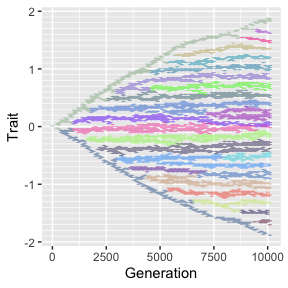

```r
comrad_tbl %>% comrad::plot_comm_trait_evolution(xgrain = 200, ygrain = 0.02)
```

Hexes of a colour represent a single species. Note the slight protraction between the actual branching time and the time speciation is detected.

Trait distribution at a single generation can also be plotted:

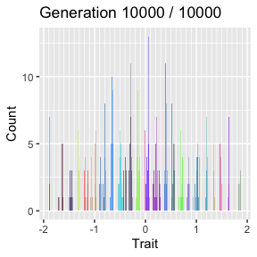

```r
comrad_tbl %>% comrad::plot_comm_traits(generation = 10000)
```

A third angle to visualize the community is through the growth curve:

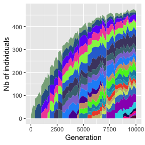

```r
comrad_tbl %>% plot_comm_size()
```

The community initially grows exponentially, until the carrying capacity at $z = 0$ is reached. The number of individuals will keep growing more slowly, as clusters push each other away and explore new parts of the trait space.

## Phylogeny reconstruction

```r
phylo <- comrad_tbl %>% comrad::sim_to_phylo()
phylo
```

[output not shown]

The tree can be plotted with standard phylogeny-plotting functions, e.g. from `ape`:

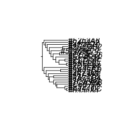

```r
phylo %>% ape::plot.phylo()
```

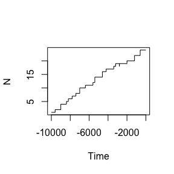

```r
phylo %>% ape::ltt.plot()
```

## Fitting diversity-dependent models to phylogenies

The main goal of `comrad` is to assess whether diversity-dependent (DD) diversification models, made from combinations of simple speciation and extinction functions, can appropriately capture the form of diversity-dependence that emerges from competition in the individual-based model. To do so,it is necessary to be able to fit said functions to the phylogenetic trees produced by the model, and evaluate their relative fit, via their maximum likelihood.

This comparison can be carried out both for ideal “complete” trees, where all the species alive at any point in time are known, including the ones extinct at present; and for “reconstructed” trees, where the extinct lineages are dropped from the tree and the likelihood must be integrated over all possible states of past diversity.

The package includes a set of functions to do so. Below, I show an example of each case (complete and reconstructed tree), fitting the simple linear DD on speciation, constant-rate extinction (LC) diversification model:

$$\lambda (N) = \lambda_0 \Big(1 - \frac{N}{K}\Big) \\
\mu(N) = \mu_0$$
with three free parameters: $\lambda_0$, the initial speciation rate when $N = 0$, $\mu_0$ the initial (but constant) extinction rate, and $K$, the equilibrium diversity.

`comrad` uses a dedicated data structure to encode these diversity-dependent models, a list containing (1) the name of the model, (2) the speciation function, (3) the extinction function, (4) a list of constraints for the initial parameter values, (5) a function used internally to check that the correct parameters are supplied, and (6) the name of the DD model in package `DDD`.

```r
dd_model <- comrad::dd_model_lc() # linear speciation, constant extinction
dd_model
```

```
#> $name
#> [1] "lc"
#>
#> $speciation_func
#> function(params, N) {
#>       pmax(params["lambda_0"] - (params["lambda_0"] - params["mu_0"]) * (N / params["k"]), 0)
#>     }
#> <environment: 0x7fb3eaa55938>
#>
#> $extinction_func
#> function(params, N) {
#>       rep(params["mu_0"], length(N))
#>     }
#> <environment: 0x7fb3eaa55938>
#>
#> $constraints
#> $constraints[[1]]
#> function(params, ...) params["lambda_0"] > 0
#> <environment: 0x7fb3eaa55938>
#>
#> $constraints[[2]]
#> function(params, ...) params["mu_0"] >= 0
#> <environment: 0x7fb3eaa55938>
#>
#> $constraints[[3]]
#> function(params, ...) params["k"] >= 1
#> <environment: 0x7fb3eaa55938>
#>
#> $constraints[[4]]
#> function(params, ...) params["lambda_0"] > params["mu_0"]
#> <environment: 0x7fb3eaa55938>
#>
#> $constraints[[5]]
#> function(params, N_max, ...) {
#>         kprime <- ceiling(params["k"] * params["lambda_0"] /
#>                             (params["lambda_0"] - params["mu_0"]))
#>         N_max <= kprime
#>       }
#> <environment: 0x7fb3eaa55938>
#>
#>
#> $params_check
#> function(params) {
#>       params_names <- names(params)
#>       if (!(length(params_names) == 3 &&
#>             all(params_names %in% c("lambda_0", "mu_0", "k"))
#>       )) {
#>         stop("params for ddmodel_lc should be \"lambda_0\", \"mu_0\" and \"k\".")
#>       }
#>     }
#> <environment: 0x7fb3eaa55938>
#>
#> $DDD_name
#> [1] 1
```

The name of each DD model is a combination of two letters, respectively specifying the diversity-dependent functions used for the speciation and extinction models:

- **l** stands for linear function
- **p** stands for power function
- **x** stands for exponential function
- **c** stands for constant (only for extinction).

There are 12 available combinations of these functions:

```r
comrad::dd_model_names()
```

```
#>  [1] "lc" "ll" "lx" "xc" "xl" "xx" "pc" "lp" "pl" "pp" "px" "xp"
```

Note that this is different from the nomenclature used in package `DDD`, where the DD models are specified by a number. For convenience, I have included a function to quickly retrieve the `DDD` code corresponding to a given DD model:

```r
comrad::dd_model_comrad_to_ddd("lc")
```

```
#> [1] 1
```

```r
comrad::dd_model_comrad_to_ddd("ll")
```

```
#> [1] 5
```

```r
comrad::dd_model_comrad_to_ddd("px")
```

```
#> [1] 15
```

### Complete tree case

In this case, the optimisation function uses the waiting time between each speciation and extinction event in the phylogeny, which must be extracted:

```r
wt_tbl <- comrad::waiting_times(phylo)
knitr::kable(wt_tbl)
```

| time | N | next_event | waiting_time | is_speciation |
| --- | --- | --- | --- | --- |
| 0 | 1 | speciation | 400 | TRUE |
| 400 | 2 | speciation | 600 | TRUE |
| 1000 | 3 | speciation | 0 | TRUE |
| 1000 | 4 | speciation | 600 | TRUE |
| 1600 | 5 | speciation | 200 | TRUE |
| 1800 | 6 | speciation | 400 | TRUE |
| 2200 | 7 | speciation | 400 | TRUE |
| 2600 | 8 | speciation | 400 | TRUE |
| 3000 | 9 | speciation | 0 | TRUE |
| 3000 | 10 | speciation | 600 | TRUE |
| 3600 | 11 | speciation | 800 | TRUE |
| 4400 | 12 | speciation | 200 | TRUE |
| 4600 | 13 | speciation | 0 | TRUE |
| 4600 | 14 | speciation | 800 | TRUE |
| 5400 | 15 | speciation | 0 | TRUE |
| 5400 | 16 | speciation | 400 | TRUE |
| 5800 | 17 | speciation | 800 | TRUE |
| 6600 | 18 | speciation | 200 | TRUE |
| 6800 | 19 | speciation | 400 | TRUE |
| 7200 | 20 | extinction | 0 | FALSE |
| 7200 | 19 | speciation | 800 | TRUE |
| 8000 | 20 | speciation | 800 | TRUE |
| 8800 | 21 | speciation | 0 | TRUE |
| 8800 | 22 | speciation | 600 | TRUE |
| 9400 | 23 | speciation | 0 | TRUE |

Second, the optimisation needs to start from a set of initial values. A utility is provided to automatically draw sets of reasonable initial values for the tree, given the model:

```r
phylos <- list()
phylos[[1]] <- phylo # the function below assumes a list of trees
init_params <- comrad::draw_init_params_dd_ml(
  phylos = phylos,
  nb_sets = 1,
  dd_model = dd_model
)[[1]]
init_params
```

```
#>     lambda_0         mu_0            k
#> 2.420365e-02 4.345841e-03 1.720000e+02
```

Alternative values may be supplied by the user, but these must be stored in a named vector with the names of the parameters for each element, as above. The `params_check()` element of the DD model object can be used to assert that the correct parameters are used.

With these elements, the model can be fit to the tree or set of trees:

```r
ml_tbl <- comrad::fit_dd_model_with_fossil(
  waiting_times_tbl = wt_tbl,
  dd_model = dd_model,
  init_params = init_params
)
```

```
#> Cycle 1
#> Cycle 2
#> Cycle 3
#> Cycle 4
#> Cycle 5
#> Cycle 6
#> Cycle 7
#> Cycle 8
#> No more cycles needed.
```

```r
knitr::kable(ml_tbl)
```

[output not shown]

### Extant lineages only

Fitting DD models to reconstructed tree is done via the `dd_ML()` function of `DDD`, called internally. In `DDD`, the likelihood is computed from a vector of branching times, so these must be extracted first:

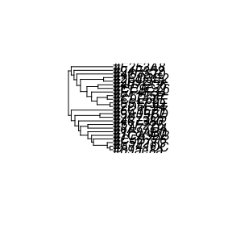

```r
# Drop extinct lineages
phylo_extant <- phylo %>%
  ape::drop.fossil()
phylo_extant %>% ape::plot.phylo()
```

```r
# Extract branching times
branching_times <- phylo_extant %>%
  ape::branching.times()
```

Using the same `dd_model` object and initial parameter values as above, it is then possible to optimise the likelihood of the model:

```r
# not run; optimisation may take a very long time
# and bugs may occur depending on the current state of DDD
ml_tbl <- comrad::fit_dd_model_without_fossil(
  branching_times =  branching_times,
  dd_model = dd_model,
  init_params = init_params
)
```

## References

M. Pontarp, J. Ripa, and P. Lundberg, *On the origin of phylogenetic structure in competitive metacommunities*, Evolutionary Ecology Research **14**, 269 (2012)